# Life expectancy of countries and healthcare budget

Barbora Ferusová - (barbora.ferusova@gmail.com)

Last edited: 2024-03-20

**Skills showcased:** - **Econometric Modeling:** Proficiency in analyzing the relationship between healthcare expenditure and life expectancy using linear and polynomial regression models. - **Statistical Analysis and Inference:** Expertise in conducting descriptive and inferential statistical analyses to derive insights from data. - **Data Visualization:** Ability to create meaningful visual representations of data and statistical models to facilitate understanding and decision-making. - **Bayesian Statistics:** Advanced skills in applying Bayesian methods to estimate model parameters and predict outcomes. - **Simulation and Predictive Modeling:** Competence in simulating data to explore hypothetical scenarios and predict their impact on life expectancy.

# Introduction

Utilizing data from the Global Health Observatory of the World Health Organization, this project embarks on an econometric journey to unravel the intricate relationship between healthcare expenditure and life expectancy across countries. By employing a blend of linear and polynomial regression analyses within a Bayesian framework, the study seeks to quantify how variations in healthcare budgets impact population longevity.

```r
# Rename columns for ease of use
df <- read_csv("data/life_data.csv") %>%
  rename(
    life_expectancy = `Life expectancy`,
    total_expenditure = `Total expenditure`
  ) %>%
  filter(!is.na(total_expenditure), Year == 2014)  # Filter in one step
```

# Descriptive statistics

Conducting an initial examination through boxplots and scatterplots to visualize the distribution and relationship between life expectancy and healthcare expenditure.

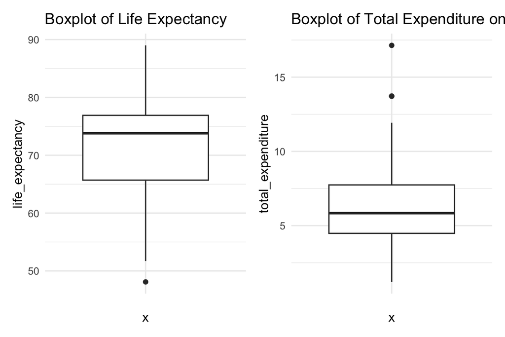

```r
# Set common plot theme parameters
theme_set(theme_minimal())
boxplot_life <- ggplot(df, aes(x = "", y = life_expectancy)) +
  geom_boxplot() +
  labs(title = "Boxplot of Life Expectancy")

boxplot_expenditure <- ggplot(df, aes(x = "", y = total_expenditure)) +
  geom_boxplot() +
  labs(title = "Boxplot of Total Expenditure on Healthcare")

# Arrange boxplots
(boxplot_life | boxplot_expenditure)
```

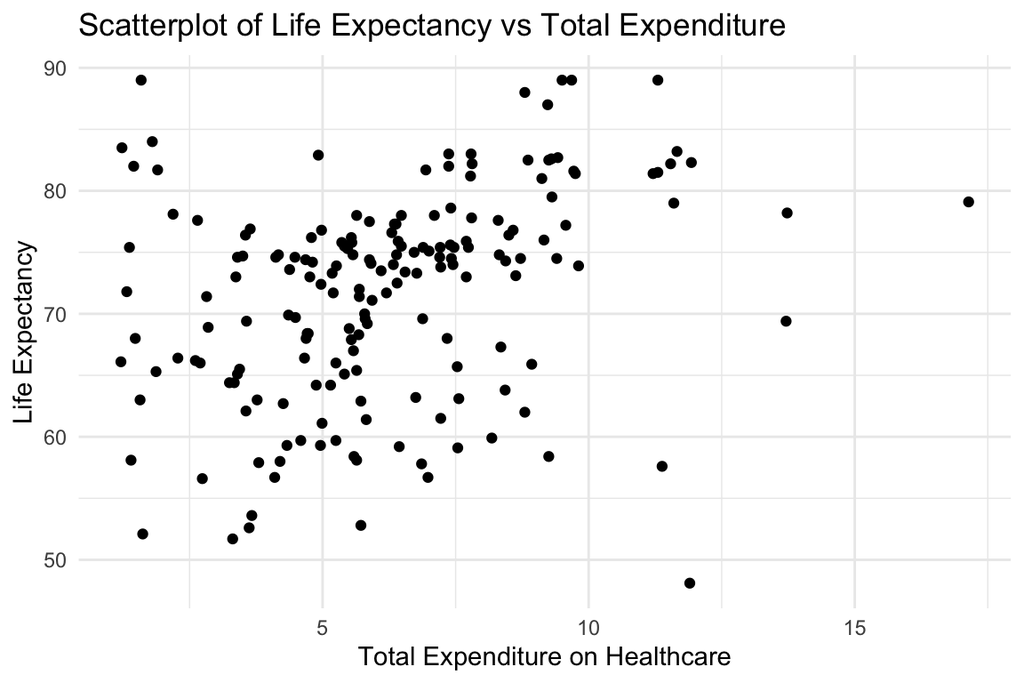

```r
# Scatterplot
ggplot(df, aes(x = total_expenditure, y = life_expectancy)) +
  geom_point() +
  labs(title = "Scatterplot of Life Expectancy vs Total Expenditure",
       x = "Total Expenditure on Healthcare",
       y = "Life Expectancy") +
  theme_minimal()
```

# Part 1: Gaussian model of life expectancy

## 1.1 Plotting the distribution of life expectancy

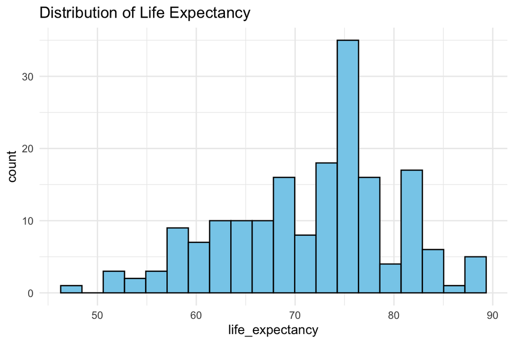

```r
# Plot distribution of life expectancy
ggplot(df, aes(x = life_expectancy)) +
  geom_histogram(bins = 20, fill = "skyblue", color = "black") +
  labs(title = "Distribution of Life Expectancy") +
  theme_minimal()
```

> Parameters to be estimated for the Gaussian distribution of life expectancy would include mean (μ) and standard deviation (σ). These parameters describe the center and spread of the distribution, respectively.

## 1.2 Model

- Prior for life expectancy: Normal distribution with mean = 72 and standard deviation = 5.

Estimating the distribution parameters of life expectancy using Bayesian priors and posterior predictive simulations, providing insights into the underlying statistical characteristics of the data.

### Prior predictive simulation

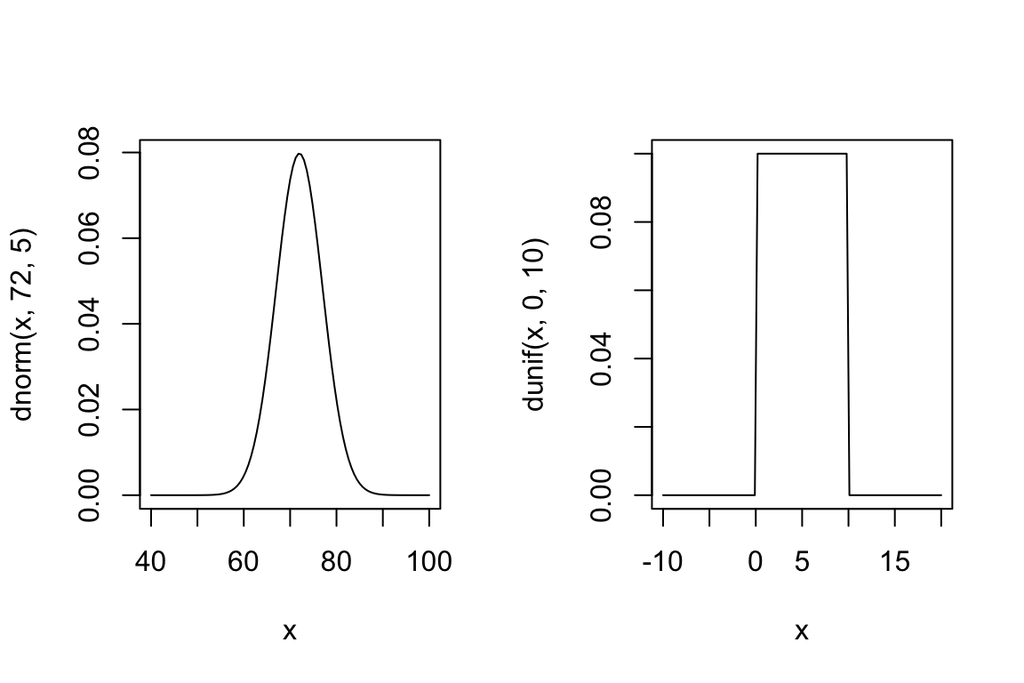

```r
# Fist, plot priors on their own
par(mfrow = c(1, 2))
plot_mu <- curve(dnorm(x, 72, 5), from= 40, to= 100) # for mu
plot_sigma <- curve(dunif(x, 0, 10), from= -10, to= 20) # for sigma
```

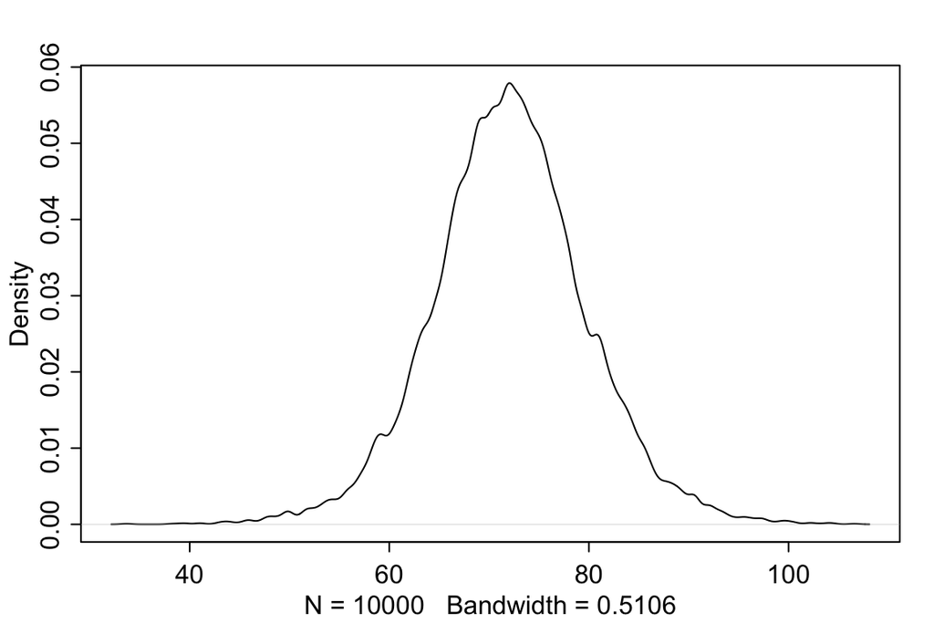

```r
# Set priors mu and sigma and sample with the priors
sample_mu <- rnorm(1e4, 72, 5)
sample_sigma <- runif(1e4, 0, 10)
prior_life <- rnorm(1e4, sample_mu, sample_sigma )
dens(prior_life)
```

```r
# do PI (89% dies between)
PI(prior_life, prob = 0.89)
```

```
##       5%      94%
## 59.84490 84.45746
```

> Normal Distribution for Mean (mu): The mean of the normal distribution for mu is set to 72, which is close to the center of the PI. The standard deviation of 5 covers a reasonable range around the mean. This prior distribution seems reasonable since it’s centered around a value within the PI, and the standard deviation allows for sufficient variability to capture the spread of the data.

## 1.3 Quadratic approximation

Using quadratic approximation to find the posterior distribution.

```r
# Define priors and model
model_notation <- alist(
  life_expectancy ~ dnorm(mu, sigma),
  mu ~ dnorm(72, 5),
  sigma ~ dunif(0, 10)
)

mv1 <- quap(model_notation, data = df)
```

## 1.4. Sample the posterior

```r
# Sample from the posterior distribution
posterior_samples <- extract.samples(mv1)

# Summarize the posterior samples
precis(posterior_samples)
```

```
##            mean        sd      5.5%     94.5%   histogram
## mu    71.623130 0.6304983 70.623329 72.631175 ▁▁▁▃▇▇▅▂▁▁▁
## sigma  8.488194 0.4427372  7.780456  9.193788    ▁▁▂▇▇▂▁▁
```

```r
round( vcov( mv1 ) , 3 )
```

```
##          mu sigma
## mu    0.392 0.000
## sigma 0.000 0.199
```

> The confidence interval of mu is pretty tight around 72, an over-fit.

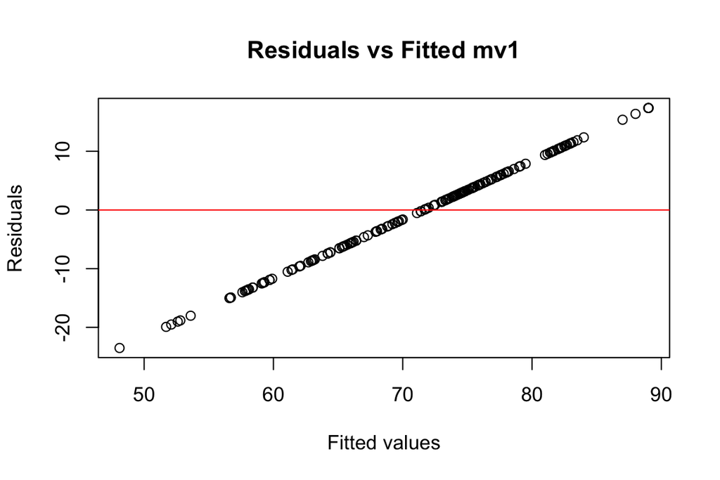

```r
# Compute the mean of the fitted values 'mu' from the posterior samples
fitted_values <- mean(posterior_samples$mu)

# Compute residuals as the difference between observed values and the mean of fitted values
observed_values <- df$life_expectancy
residuals <- observed_values - fitted_values

# Now plot residuals vs fitted values
plot(observed_values, residuals, main="Residuals vs Fitted mv1", xlab="Fitted values", ylab="Residuals")
abline(h=0, col="red")
```

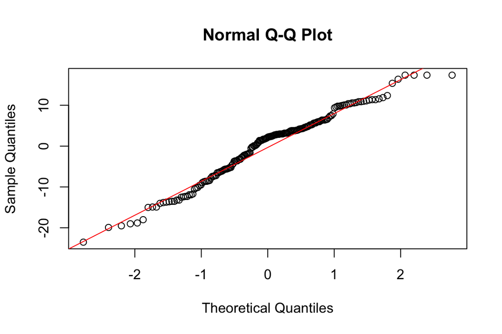

```r
# For the normality check of residuals
qqnorm(residuals)
qqline(residuals, col = "red")
```

```r
AIC(mv1)
```

```
## 'log Lik.' 1291.812 (df=2)
```

# Part 2: Linear prediction

Exploring the linear relationship between healthcare expenditure and life expectancy, applying Bayesian inference to estimate model parameters and assess their impacts.

## 2.1 Model

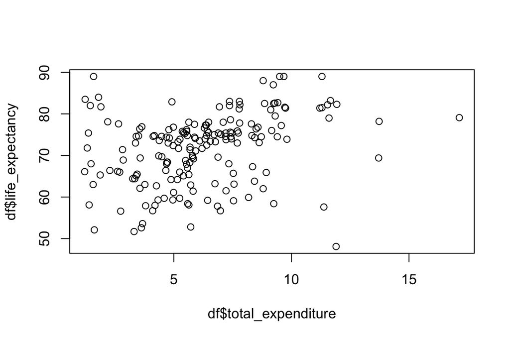

```r
plot(df$life_expectancy ~ df$total_expenditure)
```

Describing the *likelihood*

```r
# Likelihood of life_expectancy
df$life_expectancy ~ dnorm(mu, sigma)
```

```
## df$life_expectancy ~ dnorm(mu, sigma)
```

> We expect y (life_expectancy) to follow a Gaussian distribution defined by a mean and standard deviation.

Describing the **the linear model**

```r
# Linear model
x <- df$total_expenditure
xbar <- mean(x)
#mu <- a + b*(x - xbar)
```

> Here we define the linear model as a deterministic expression of mu, with parameters a,b and x. Inside the parentheses allow for a deviation of an individual observation of x from the mean.

Describing the parameter **alpha**

```r
# a
a ~ dnorm(72,5) # intercept
```

```
## a ~ dnorm(72, 5)
```

Describing the parameter **beta**

```r
# b
b ~ dlnorm(0,1) # slope
```

```
## b ~ dlnorm(0, 1)
```

> Beta is the slope parameter of my regression to be estimated. Since we are suggesting a positive relationship, we can’t suggest same probability of negative and positive values. And so the mean is a flat slope of 0 with a standard deviation of 1.

> Together they’re a linear model. This assumes that the data follows a linear relationship which isn’t the case really. There could also be other parameters that influence life expectancy.

## 2.2 Priors

Now I have three parameters to estimate - the standard deviation parameter *sigma* and the two new parameters - *a* and *b*.

### Prior predictive simulation

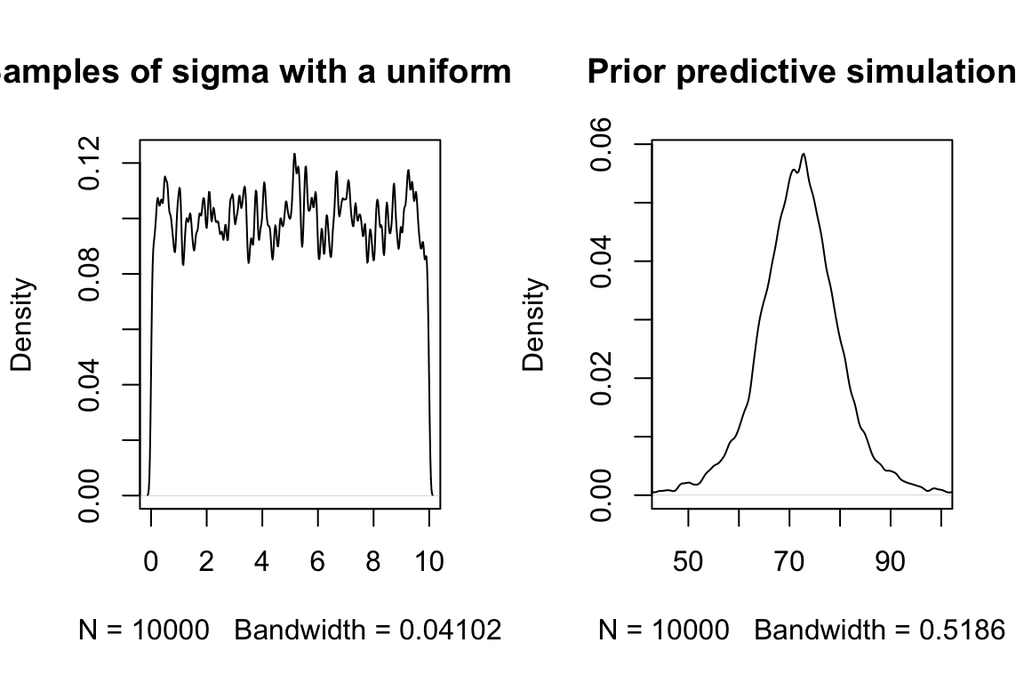

```r
par(mfrow = c(1, 2))
# Define
N <- 1e4
sample_a <- rnorm(N,72,5) # intercept
sample_b <- rlnorm(N,0,0.5) # slope
sample_sig <- runif(N,0,10)
# plot sigma
dens(sample_sig, xlim = c(0, 10), adj = 0.1, main = "Samples of sigma with a uniform prior")

# Prior predictive simulation
prior_pred_sim <- rnorm(N, sample_a, sample_b * sample_sig)

# Plot Prior predictive simulation
dens(prior_pred_sim,  xlim = c(45, 100), main = "Prior predictive simulation")
```

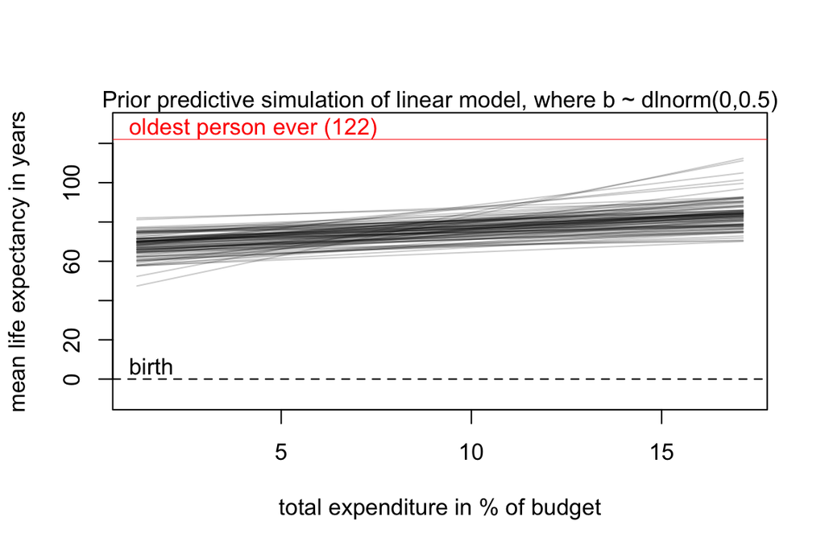

```r
N <- 100
sample_a <- rnorm(N,72,5) # intercept
sample_b <- rlnorm(N,0,0.5) # slope

# Prior predictive simulation of the linear model
plot(NULL, xlim=range(df$total_expenditure), ylim=c(-10, 130),
     xlab="total expenditure in % of budget", ylab="mean life expectancy in years")
abline(h=0, lty=2)
text(1,122, "oldest person ever (122)", col = "red", adj = c(0, -.3))
abline(h=122, lty=1, lwd=0.5, col="red")
text(1,0, "birth", adj = c(0,-.3))
mtext("Prior predictive simulation of linear model, where b ~ dlnorm(0,0.5)")
for (i in 1:N) curve(sample_a[i] + sample_b[i]*(x-xbar),
                     from=min(df$total_expenditure), to=max(df$total_expenditure), add=TRUE,
                     col=col.alpha("black", 0.2))
```

> Limitations of this model are that it would not work for very high values of expenditure

## 2.3 Finding the posterior distribution (another)

Using quap to find the posterior distribution.

```r
# Here's a dataframe again
df2 <- df[, c("life_expectancy", "total_expenditure"), drop = FALSE]

model_notation_linear <- alist(
                      life_expectancy ~ dnorm(mu, sigma),
                      mu <- a + b*(x - xbar),
                      a ~ dnorm(72,5),
                      b ~ dlnorm(0,1),
                      sigma ~ dunif(0,10)
)
# beta dis depending on the magnitude of the relationship
mv2 <- quap(model_notation_linear, data = df2)
```

#### 2.3.1 Tables of marginal distributions

Describing the findings using the marginal posterior distributions.

```r
# Sample from the posterior distribution
posterior_samples2 <- extract.samples(mv2)

# Summarize the posterior samples
precis(posterior_samples2)
```

```
##             mean        sd       5.5%     94.5%   histogram
## a     71.6384885 0.5882586 70.7160343 72.580741 ▁▁▁▂▇▇▅▁▁▁▁
## b      0.9248305 0.2190974  0.5774161  1.274722   ▁▁▁▅▇▅▂▁▁
## sigma  8.0612595 0.4199411  7.3964321  8.739318    ▁▁▂▇▇▂▁▁
```

```r
round( vcov( mv2 ) , 3 )
```

```
##           a      b  sigma
## a     0.354  0.000  0.000
## b     0.000  0.048 -0.002
## sigma 0.000 -0.002  0.180
```

#### 2.3.2 Plotting posterior inference

Plotting the posterior inference, starting with a simple line, then adding uncertainty around the mean line, then incorporating standard deviation *sigma* and it’s uncertainty as well.

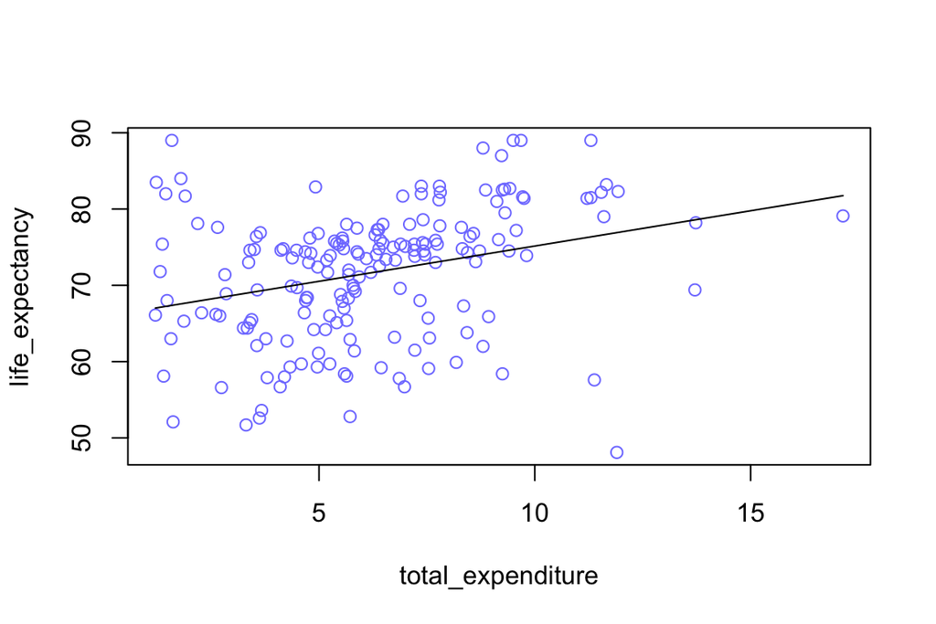

```r
# mean line
plot(life_expectancy ~ total_expenditure , data=df2 , col=rangi2 )
a_map <- mean(posterior_samples2$a)
b_map <- mean(posterior_samples2$b)
curve( a_map + b_map*(x - xbar) , add=TRUE )
```

> Here we can see the mean regression line of the relationship at hand fitted onto the data points. We can see the magnitude of the relationship.

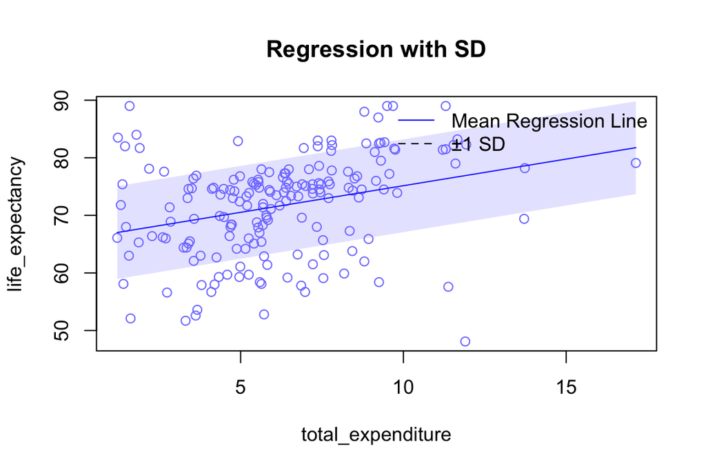

```r
# Adding standard deviation onto the scatterplot
# Calculate necessary stats
a_map <- mean(posterior_samples2$a)
b_map <- mean(posterior_samples2$b)
sigma_mean <- mean(posterior_samples2$sigma)
x_seq <- seq(min(df2$total_expenditure), max(df2$total_expenditure), length.out=100)
y_reg <- a_map + b_map * (x_seq - xbar)

# Plot the scatter plot
plot(life_expectancy ~ total_expenditure, data=df2, col=rangi2, main="Regression with SD")

# Plot mean regression line
lines(x_seq, y_reg, col="blue")

# Calculate the standard deviation of posterior samples for regression coefficients
a_sd <- sd(posterior_samples2$a)
b_sd <- sd(posterior_samples2$b)

# Add shaded area for SD around the regression line
y_upper <- y_reg + sigma_mean
y_lower <- y_reg - sigma_mean
polygon(c(rev(x_seq), x_seq), c(rev(y_lower), y_upper), col=adjustcolor(rangi2, alpha=0.2), border=NA)

# Add labels and legend
legend("topright", legend=c("Mean Regression Line", "±1 SD"), col=c("blue", "black"), lty=c(1, 2), bty="n")
```

> The shaded area represents the uncertainty around the mean regression line, showing one standard deviation above and below the mean line.

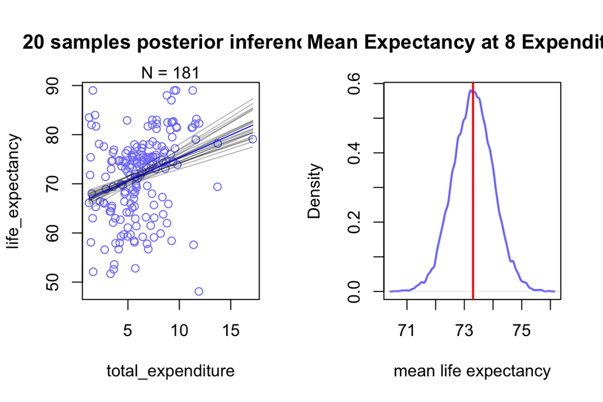

```r
par(mfrow = c(1, 2))

# SHOWING THE UNCERTAINITY OF ALPHA AND BETA REGRESSION COEFICCENTS
# resample the model
set.seed(123)
N <- 181
dN <- df2[1:181,]

mv3 <- quap(alist(
                  life_expectancy ~ dnorm(mu, sigma),
                  mu <- a + b*(x - xbar),
                  a ~ dnorm(72,5),
                  b ~ dlnorm(0,1),
                  sigma ~ dunif(0,10)), data = dN)

# extract 20 samples from the posterior
post20 <- extract.samples( mv3 , n=20 )

# calculating some stats
a_map20 <- mean(post20$a)
b_map20 <- mean(post20$b)
x_seq20 <- seq(min(df2$total_expenditure), max(df2$total_expenditure), length.out=100)
y_reg20 <- a_map20 + b_map20 * (x_seq20 - xbar)

# display raw data and sample size
plot(
     dN$total_expenditure, dN$life_expectancy,
     xlim=range(df2$total_expenditure), ylim=range(df2$life_expectancy),
     col=rangi2,
     xlab="total_expenditure", ylab="life_expectancy",
     main = "20 samples posterior inference"
     )
mtext(concat("N = ",N))

# plot the lines, with transparency
for ( i in 1:20 )
  curve( post20$a[i] + post20$b[i]*(x-mean(dN$total_expenditure)) ,
                        col=col.alpha("black",0.3) , add=TRUE )
lines(x_seq20, y_reg20, col="blue")


# see a random value of total_expenditure
# just like if we sliced the regression line at 8
mu_at_50 <- posterior_samples2$a + posterior_samples2$b * ( 8 - xbar )
dens( mu_at_50 , col=rangi2 , lwd=2 , xlab="mean life expectancy", main = "Mean Expectancy at 8 Expenditure")
abline(v = mean(mu_at_50), col = "red", lwd = 2)
```

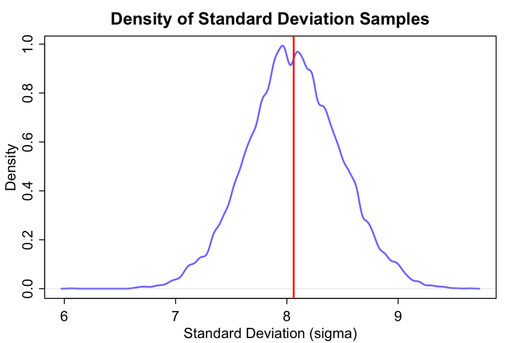

```r
# Extracting standard deviation samples from the posterior distribution
sigma_samples <- posterior_samples2$sigma

# Plotting the density of standard deviation samples
dens(sigma_samples, col = rangi2, lwd = 2, xlab = "Standard Deviation (sigma)", main = "Density of Standard Deviation Samples")

# Adding a vertical line at the mean standard deviation
abline(v = mean(sigma_samples), col = "red", lwd = 2)
```

> Here we can see the posterior distribution of values of sigma around the mean sigma. This visualization allows us to understand the variability in the standard deviation and its uncertainty in the context of the model. Basically showing the uncertainty of the uncertainty.

## 2.4 Prediction

Let’s play with a hypothetical scenario: there is a new official elected in an imaginary country and they want to spend 20% of their budget on healthcare. What would happen?

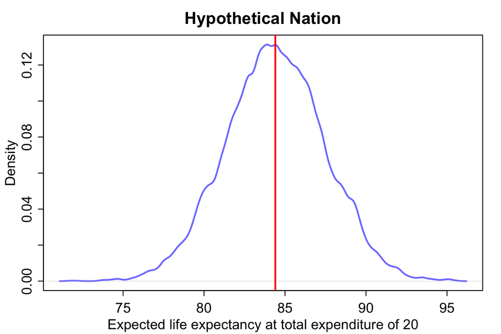

```r
# Extract posterior samples of coefficients and standard deviation
a_samples <- posterior_samples2$a
b_samples <- posterior_samples2$b

# Calculate life expectancy for total_expenditure = 20 using each set of coefficients
life_expectancy_samples <- a_samples + b_samples * (20 - mean(dN$total_expenditure))

# Calculate the mean and credible interval of life expectancy predictions
life_expectancy_mean <- mean(life_expectancy_samples)
life_expectancy_ci <- quantile(life_expectancy_samples, c(0.025, 0.975))

dens(life_expectancy_samples, col = rangi2, lwd = 2, xlab = "Expected life expectancy at total expenditure of 20", main = "Hypothetical Nation")
abline(v = life_expectancy_mean, col = "red", lwd = 2)
```

# Part 3: Polynomial regression

Extending the analysis to a polynomial framework to capture non-linear effects, enhancing the model’s predictive power and relevance to real-world scenarios.

## 3.1 Generative model to simulate data

Here I will look at hypothetical higher expenditures. I create the relationship and simulate data from it. And then use quadratic approximation to estimate my creation. First, I simulate 1000 observations of total expenditure, ranging from 0 to 50. We are then going to standardize this data to ensure my estimates are accurate.

```r
set.seed(420)

# Number of data points
n <- 1000

# Generate total expenditure on healthcare (ranging from 0 to 100)
total_expenditure <- runif(n, min = 0, max = 50)

# Standardize total expenditure
total_expenditure_s <- scale(total_expenditure)
```

Here I encode the relationship between the two variables myself - using a polynomial function, which is adding another parameter b2 which interacts with the square of my *total expenditure* observation.

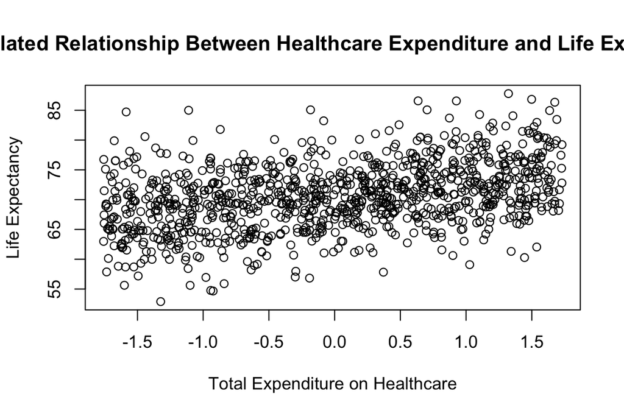

```r
# intercept indicating the base life expectancy when total expenditure is zero
a <- 70

# b1 representing the linear effect of total expenditure on life expectancy
b1 <- 2

# b2 representing the quadratic effect of total expenditure on life expectancy
b2 <- 0.5

# Create the quadratic relationship equation using standardized variables
mu <- a + b1 * total_expenditure_s + b2 * total_expenditure_s^2

# Add random noise - my sigma
life_expectancy <- mu + rnorm(n, mean = 0, sd = 5)

# Create a data frame
polynomial_data <- data.frame(life_expectancy = life_expectancy, total_expenditure = total_expenditure, total_expenditure_s = total_expenditure_s)

# Plot the simulated relationship
plot(life_expectancy ~ total_expenditure_s, data = polynomial_data,
     main = "Simulated Relationship Between Healthcare Expenditure and Life Expectancy",
     xlab = "Total Expenditure on Healthcare", ylab = "Life Expectancy")
```

## 3.2 Quadratic approxmation to estimate the posterior

```r
# Quadratic approximation for the simulated data
mv_polynomial <- quap(
  alist(
    life_expectancy ~ dnorm(mu, sigma),
    mu <- a + b1 * total_expenditure_s + b2 * total_expenditure_s^2,
    a ~ dnorm(70, 10),
    b1 ~ dlnorm(0, 1),
    b2 ~ dlnorm(0, 1),
    sigma ~ dunif(0, 10)
  ),
  data = polynomial_data
)
```

```r
# Summary of posterior estimates
polynomial_samples <- extract.samples(mv_polynomial)

# Summarize the posterior samples
precis(polynomial_samples)
```

```
##            mean        sd       5.5%      94.5%      histogram
## a     70.235002 0.2215706 69.8804660 70.5949794      ▁▁▂▇▇▃▁▁▁
## b1     2.125327 0.1604239  1.8677331  2.3823612 ▁▁▁▁▂▃▇▇▅▂▁▁▁▁
## b2     0.309688 0.1515133  0.0668169  0.5528851   ▁▁▁▂▃▇▇▅▂▁▁▁
## sigma  5.050034 0.1119880  4.8723928  5.2278660      ▁▁▂▅▇▅▂▁▁
```

> b2 parameter is kind of off from the 0.5 that we set, but it’s still within the confidence (compatibility) interval.